# DESeq2+Glimma

Giorgio Bolchi

5/6/2022

## Description

This script is a combination of the **DESeq2** Differential Gene Expression Analysis tool and the **Glimma** interactive html graphic tool available through **Bioconductor**.

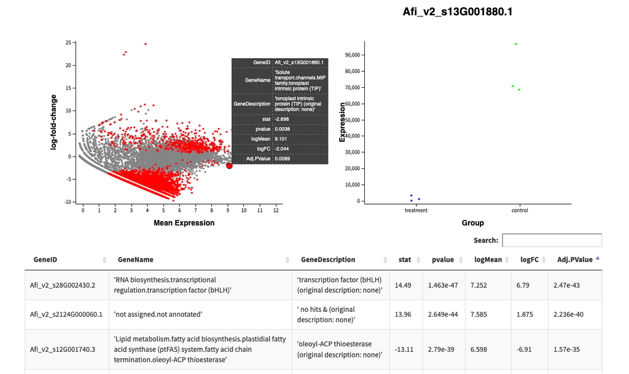

### Sources:

DESeq2:

Glimma:

- https://github.com/Shians/Glimma
- https://bioconductor.org/packages/release/bioc/manuals/Glimma/man/Glimma.pdf (manual)

## Script

#### Load libraries

(If not installed yet)

```r
install.packages("BiocManager")
BiocManager::install("DESeq2")
BiocManager::install("Glimma")
```

```r
library("DESeq2")
library("Glimma")
```

#### Load data

Replace *YOUR_COUNTS_DATA.csv* by your raw counts .csv file. If necessary, change the separation character to match your file.

```r
countData <- read.csv('YOUR_COUNTS_DATA.csv', header = TRUE, sep = ",")
```

Replace *YOUR_METADATA.csv* by your metadata .csv file (with sample ids, and treatment names).

```r
colData <- read.csv('YOUR_METADATA.csv', header = TRUE, sep = ",",)
colnames(colData)<-c("id","group")
```

### DESeq2

Construct DESeqDataset object

```r
dds <- DESeqDataSetFromMatrix(countData=countData,
                              colData=colData,
                              design=~group,
                              tidy = TRUE)
```

Run DESeq function

```r
dds <- DESeq(dds)
```

Extract results in a new dataframe. Make sure to change the *treatment* and *control* to your own.

```r
res <- results(dds, contrast=c("group", "treatment", "control"))
```

It is possible to already export these results as a .csv file for further analysis in other programs.

```r
write.csv(as.data.frame(res), file="results.csv")
```

The file would look like this.

```r
head(read.csv("results.csv"))
```

```
##                       X   baseMean log2FoldChange     lfcSE       stat
## 1  Afi_v2_s189G000110.2 194548.636     4.81609140 0.4254627 11.3196548
## 2   Afi_v2_s74G000210.2  45016.653     0.52233627 0.1926285  2.7116249
## 3   Afi_v2_s48G000990.2  33289.799     0.08425995 0.3600550  0.2340197
## 4   Afi_v2_s20G000170.2  10534.156     5.86013452 0.7551303  7.7604283
## 5   Afi_v2_s15G003180.3  35236.665    -0.85785455 0.6148753 -1.3951683
## 6 Afi_v2_s3215G000080.1   7514.873     5.39865423 0.5780653  9.3391769
##         pvalue         padj
## 1 1.048841e-29 1.967392e-26
## 2 6.695432e-03 1.507700e-02
## 3 8.149697e-01 9.062854e-01
## 4 8.464304e-15 6.620692e-13
## 5 1.629651e-01 2.733138e-01
## 6 9.708590e-21 2.731674e-18
```

Sanity summary check.

```r
summary(res)
```

```
##
## out of 19481 with nonzero total read count
## adjusted p-value < 0.1
## LFC > 0 (up)       : 829, 4.3%
## LFC < 0 (down)     : 8054, 41%
## outliers [1]       : 775, 4%
## low counts [2]     : 1824, 9.4%
## (mean count < 0)
## [1] see 'cooksCutoff' argument of ?results
## [2] see 'independentFiltering' argument of ?results
```

Head the results by padj.

```r
head(res[order(res$padj),], n=5)
```

```
## log2 fold change (MLE): group treatment vs control
## Wald test p-value: group treatment vs control
## DataFrame with 5 rows and 6 columns
##                        baseMean log2FoldChange     lfcSE      stat      pvalue
##                       <numeric>      <numeric> <numeric> <numeric>   <numeric>
## Afi_v2_s28G002430.2    1410.977        6.79005  0.468698   14.4871 1.46291e-47
## Afi_v2_s2124G000060.1  1967.290        1.87511  0.134299   13.9623 2.64931e-44
## Afi_v2_s12G001740.3     733.392       -6.90966  0.526949  -13.1126 2.78983e-39
## Afi_v2_s1G001440.1      714.523       -6.91911  0.529875  -13.0580 5.72183e-39
## Afi_v2_s5G008650.1      876.314       -6.83197  0.561754  -12.1619 4.96181e-34
##                              padj
##                         <numeric>
## Afi_v2_s28G002430.2   2.46969e-43
## Afi_v2_s2124G000060.1 2.23628e-40
## Afi_v2_s12G001740.3   1.56993e-35
## Afi_v2_s1G001440.1    2.41490e-35
## Afi_v2_s5G008650.1    1.67531e-30
```

#### PCA

Using the DESEQ2 plotPCA

```r
vsdata <- vst(dds, blind=FALSE, fitType = c("local"))
```

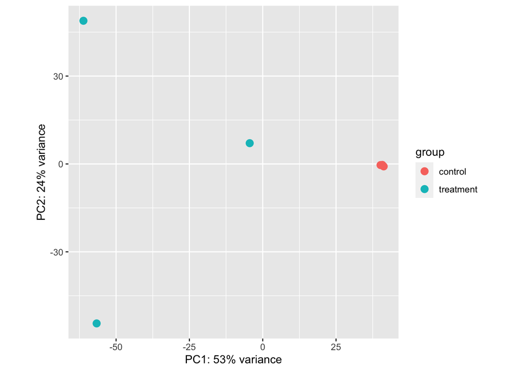

```r
plotPCA(vsdata, intgroup="group")
```

#### Plot gene expression

The boundaries of the plot are set to the minimum and maximum log2FoldChange.

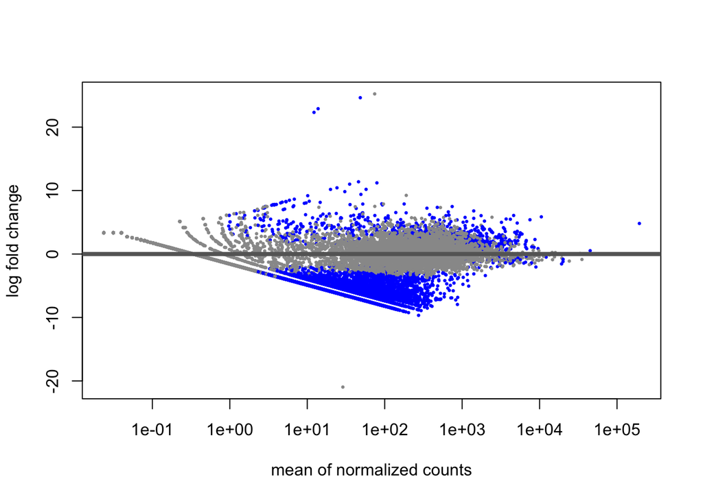

```r
plotMA(res, ylim= c(min(res$log2FoldChange, na.rm=TRUE), max(res$log2FoldChange, na.rm=TRUE)))
```

Further down, it will be possible to interact and explore the data behind this figure (here static) with the Glimma html interface.

### Glimma

The Glimma tool requires the data to be reshaped in a few dataframes so that they can be correctly plotted. First of all, an *anno* dataframe that will contain the data and respective annotations of the interactive plot.

```r
anno <- as.data.frame(res)
```

```r
anno$GeneID <- row.names.data.frame(anno) # Add GeneID as a column instead of just the rownames so that the glMDPlot() function can read and annotate the GeneIDs on the graph.
```

#### Connect GeneNames to GeneIDs

```r
gene_names <- read.csv('GENENAMES.csv', header = TRUE, sep = ",",)

anno<- cbind(anno, GeneName = "") # add a new empty column for Gene Names in the anno dataframe
anno<- cbind(anno, GeneDescription = "") # add a new empty column for Gene Descriptions in the anno dataframe
```

In order to connect the *GeneNames* and *GeneDescriptions* to the respectively correspondent *GeneIDs* in the *anno* dataframe, we use the following loop.

```r
i=0
p=0

for (i in 1:nrow(anno)){

  anno[i,8] <- gene_names[(which(gene_names$GeneID == anno[i,7])) # the which() function gives the rowname where gene_names$GeneID is equal to the GeneID in the anno file.
                          ,3] # 3 = GeneID column  of the gene_names file

  anno[i,9] <- gene_names[(which(gene_names$GeneID == anno[i,7]))
                          ,4] # 4 = DESCRIPTION column  of the gene_names file

  #It should take a minute or so.
}
```

#### glMDPlot

A few more subsets have to be defined in order to generate the interactive Glimma plot.

```r
padj <- res[, 'padj'] # subset the padj column from the results
```

```r
padj[ is.na(padj) ] <- 1 # NA values are replaced by '1' values.
```

```r
status <- as.numeric(padj < 0.01) # the status file gathers together all the padj values smaller than 0.01. It will be used by the glMDPlot() function. It is a vector giving the control status of the the data points.

# note: it is possible to modify the threshold of the padj filter. Here, only the the datapoints with a padj < 0.01 will be highlighted.
```

Here the padj threshold is set to 0.01 (all the datapoints below this threshold will appear in red on the graph, all the others will stay grey)

```r
groups <- colData(dds)[ ,'group'] # which experimental factors to take along
```

```r
colors <- c('blue', 'blue', 'blue', 'green', 'green', 'green') #  color of the triplicat points. Here the 3 first all in the same group (treatment), the 3 others are in the compared group (control).
```

```r
display <- c("GeneID","GeneName","GeneDescription", "stat","pvalue") # which annotation (from mcols(dds) ) and numeric data to show. Note: the logMean, logFC and padj are always automatically added anyway.
```

Finally, we can generate the plot.

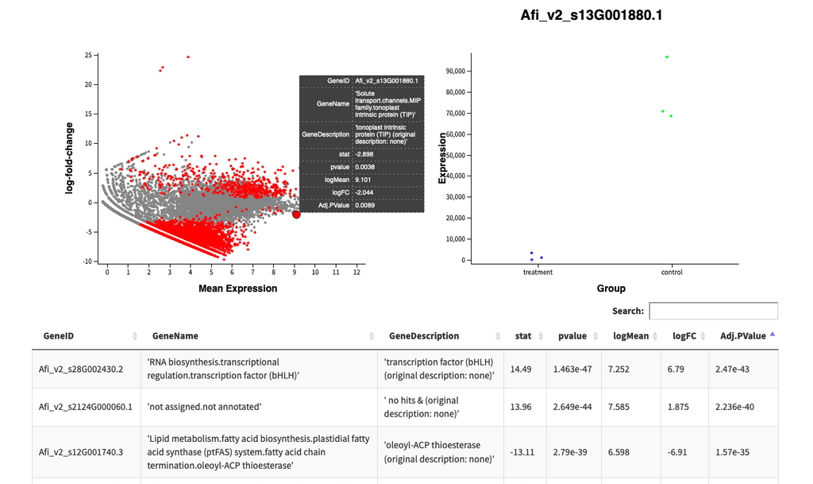

```r
glMDPlot(res,
         status=status,
         counts=counts(dds),
         samples=colnames(dds),
         sample.cols=colors,
         anno=anno,
         groups=groups,
         display.columns=display,
         html='plot_Glimma', # output name
         launch= FALSE) # if TRUE, will launch the html interactive plot right after its generation.
```

The output objecti is a folder containing the html interactive plot file.  
On the plot, it is possible to browse through the datapoints, search for a specific gene, sort by foldchange or padj, etc..